# Social Network Analysis

Michaela Fricova

2/20/2023

## #3 Social Networks in the Bank Wiring Room

This project is the 3/8 part of my mini-series on social network analysis. The goal of this series is to start with the very basics of network analysis, such as with the concepts of centrality and assortativity, and progress towards more advanced topics, including Erdős-Rényi and Configuration models, as well as Exponential family random graphs. In this third project, I analyze the **Bank Wiring Room** data set, an observational study conducted **in 1939 by F. Roethlisberger and W. Dickson at the Western Electric plant**. This data documents the network of fourteen employees: two inspectors (denoted I), three solderers (denoted S) and nine wiremen (denoted W). For the analysis, I interpreted the roles of each employee type as follows: **inspectors** regulate and manage the plant’s division, **solderers** join or mend metal materials, and **wiremen** maintain electrical equipment. The researchers collected data on the network interactions between these individuals for six different behaviors: **horseplay, arguments over open windows, antagonistic behavior generally, giving help with work tasks, trading work tasks, and friendship**. Additionally, the data was considered in an asymmetric manner, indicating a possible lack of mutuality between two actors.

The data was originally gathered by Roethlisberger and Dickson in order to measure the “Hawthorne Effect,” meaning the way in which individuals alter (most typically by improving) their behavior when they know that they are being watched. At the time, the discipline of social network analysis was not nearly as established as it is now, and they did not have the computer power to conduct the kind of analyses that are now possible. For this reason, I return to this dataset from 1939 to ask new social network analysis questions, such as whether the network structures for pro-social behaviors (horseplay, friendship, helping one another with tasks) are consistent, and whether they significantly **diverge from the network structures for anti-social behaviors** (arguments over windows) and antagonistic behavior generally. Also, it is interesting to investigate whether the **position and employment level** influence tie formation in the pro-social and anti-social networks.

### Loading the necessary packages

Multiple new packages are needed in this part of the network analysis mini-series. The igraph and integraph packages are used for baseline network graphics, whereas the multigraph package enables us to graph complex network structures where there can be multiple edges between a given pair of nodes. The linkcomm package identifies separate communities within a given network. Further, the concoR and blockmodeling packages are used for identifying structural equivalence in the networks. What is structural equivalence? Two nodes are exactly structurally equivalent if they have exactly the same ties to exactly the same other nodes. But this is quite a strong concept. That is why, we usually look for structurally similar cluster (as opposed to structurally equivalent nodes) in the network. To aid this identification of structurally similar clusters, we also use the data-tree package, which hierarchically clusters the network.

```r
library(multigraph)
library(linkcomm)
library(tibble)
library(concoR)
detach("package:concoR", unload=T)
library(ergm)
detach(package:ergm)
require(intergraph)
require(igraph)
require(blockmodeling)
library(data.tree)
library(RColorBrewer)
knitr::opts_chunk$set(echo = TRUE)
options(digits = 2)
```

### Loading the datasets and generating networks

I start by loading datasets for the five networks:

1. undirected network of friendship ties,
2. directed network of help and pro-social behaviour,
3. undirected games network,
4. undirected network of antagonistic behavior and, finally,
5. undirected network of arguments over open windows.

[figure not shown]

[figure not shown]

### Constructing adjacency matrices for each network

I create adjacency matrices for each of the five networks separately. Given that the helping network has directed ties, I have to separately consider outgoing and incoming edges. Additionally, I make the ties in the anatagonistic behaviour network and in the network of arguments over open windows, negative (multiply them by -1).

```r
# (1) Whether people seem to like one another (undirected, “POS”)
liking <- read.csv("wiring_RDPOS.csv", header = T, row.names = 1)
liking_g <- graph_from_adjacency_matrix(as.matrix(liking),mode = "undirected")
liking_adj_matrix <- as.matrix(get.adjacency(liking_g))

# (2) Whether someone helped another (directed, “HLP”)
helping <- read.csv("wiring_RDHLP.csv", header = T, row.names = 1)
helping_g <- graph_from_adjacency_matrix(as.matrix(helping),mode = "directed")
helping_adj_matrix <- as.matrix(get.adjacency(helping_g))
helping_both_matrix <- rbind(helping_adj_matrix, t(helping_adj_matrix))

# (3) Whether people played games together and horsed around (undirected,“GAM”)
games <- read.csv("wiring_RDGAM.csv", header = T, row.names = 1)
games_g <- graph_from_adjacency_matrix(as.matrix(games),mode = "undirected")
games_adj_matrix <-  as.matrix(get.adjacency(games_g))

# (4) Whether people had an antagonistic relationship (undirected,“NEG”)
negative <- read.csv("wiring_RDNEG.csv", header = T, row.names = 1)
negative_g <- graph_from_adjacency_matrix(as.matrix(negative),mode = "undirected")
negative_adj_matrix <- (-1)*as.matrix(get.adjacency(negative_g))

# (5) Whether people got into arguments/conflict (undirected, “CON”)
arguments <- read.csv("wiring_RDCON.csv", header = T, row.names = 1)
arguments_g <- graph_from_adjacency_matrix(as.matrix(arguments),mode = "undirected")
arguments_adj_matrix <- (-1)*as.matrix(get.adjacency(arguments_g))
```

### Binding the seperate adjacency metrices into one combined adjacency matrix

Subsequently, I bind all the separate adjacency matrices together to create a combined adjacency matrix. And, based on the matrix results, I calculate the structural equivalence classes. Two workers at the factory are perceived perfectly structurally equivalent if they have the exact same friends, if they play with the exact same other workers at the factory, if they have the exact same enemies and argue with the exact same other workers and, finally, if they help and receive help from the exact same others. Since this concept of perfect structural equivalence, aka perfect social equivalence is a very strong one, I also look at imperfect, structural similarity. I group the workers into clusters of socially similar others, instead of perfectly equal others.

```r
all_relationship_matrix <- rbind(liking_adj_matrix, helping_both_matrix, games_adj_matrix, negative_adj_matrix, arguments_adj_matrix)
all_relationship_matrix
```

```
##    I1 I3 W1 W2 W3 W4 W5 W6 W7 W8 W9 S1 S2 S4
## I1  0  0  0  0  1  0  0  0  0  0  0  0  0  0
## I3  0  0  0  0  0  0  0  0  0  0  0  0  0  0
## W1  0  0  0  0  1  1  0  0  0  0  0  1  0  0
## W2  0  0  0  0  0  0  0  0  0  0  0  0  0  0
## W3  1  0  1  0  0  1  0  0  0  0  0  1  0  0
## W4  0  0  1  0  1  0  0  0  0  0  0  1  0  0
## W5  0  0  0  0  0  0  0  0  0  0  0  0  0  0
## W6  0  0  0  0  0  0  0  0  0  0  0  0  0  0
## W7  0  0  0  0  0  0  0  0  0  1  1  1  0  0
## W8  0  0  0  0  0  0  0  0  1  0  1  0  0  1
## W9  0  0  0  0  0  0  0  0  1  1  0  0  0  1
## S1  0  0  1  0  1  1  0  0  1  0  0  0  0  0
## S2  0  0  0  0  0  0  0  0  0  0  0  0  0  0
## S4  0  0  0  0  0  0  0  0  0  1  1  0  0  0
## I1  0  0  0  0  0  0  0  0  0  0  0  0  0  0
## I3  0  0  0  0  0  0  0  0  0  0  0  0  0  0
## W1  0  0  0  0  1  0  0  0  0  0  1  1  0  0
## W2  0  0  0  0  1  1  0  0  0  0  0  1  0  0
## W3  0  0  0  1  0  0  0  0  0  0  0  0  0  0
## W4  0  0  1  0  1  0  0  1  0  0  0  0  0  0
## W5  0  0  0  0  1  0  0  0  0  0  0  0  0  0
## W6  0  0  0  0  1  0  0  0  1  1  1  0  0  0
## W7  0  0  0  0  0  0  0  0  0  0  0  0  0  1
## W8  0  0  0  0  0  0  0  1  1  0  1  0  0  0
## W9  0  0  0  0  0  0  0  0  0  0  0  0  0  1
## S1  0  0  0  0  0  0  0  0  1  0  0  0  0  0
## S2  0  0  0  0  0  0  0  1  0  0  0  0  0  0
## S4  0  0  0  0  0  1  0  0  0  1  0  0  0  0
## I1  0  0  0  0  0  0  0  0  0  0  0  0  0  0
## I3  0  0  0  0  0  0  0  0  0  0  0  0  0  0
## W1  0  0  0  0  0  1  0  0  0  0  0  0  0  0
## W2  0  0  0  0  1  0  0  0  0  0  0  0  0  0
## W3  0  0  1  1  0  1  1  1  0  0  0  0  0  0
## W4  0  0  0  1  0  0  0  0  0  0  0  0  0  1
## W5  0  0  0  0  0  0  0  0  0  0  0  0  0  0
## W6  0  0  0  0  0  1  0  0  0  1  0  0  1  0
## W7  0  0  0  0  0  0  0  1  0  1  0  1  0  0
## W8  0  0  0  0  0  0  0  1  0  0  0  0  0  1
## W9  0  0  1  0  0  0  0  1  0  1  0  0  0  0
```

[output cut: 30 more lines]

```
## S4  0 -1  0  0  0  0  0  0  0  0  0  0  0  0
## I1  0  0  0  0  0  0  0  0  0  0  0  0  0  0
## I3  0  0  0  0  0  0  0  0  0  0  0  0  0  0
## W1  0  0  0  0  0  0  0  0  0  0  0  0  0  0
## W2  0  0  0  0  0  0  0  0  0  0  0  0  0  0
## W3  0  0  0  0  0  0  0  0  0  0  0  0  0  0
## W4  0  0  0  0  0  0 -1 -1 -1  0 -1  0  0  0
## W5  0  0  0  0  0 -1  0 -1  0  0  0 -1  0  0
## W6  0  0  0  0  0 -1 -1  0 -1 -1 -1 -1  0 -1
## W7  0  0  0  0  0 -1  0 -1  0 -1 -1  0  0 -1
## W8  0  0  0  0  0  0  0 -1 -1  0 -1 -1  0 -1
## W9  0  0  0  0  0 -1  0 -1 -1 -1  0 -1  0  0
## S1  0  0  0  0  0  0 -1 -1  0 -1 -1  0  0 -1
## S2  0  0  0  0  0  0  0  0  0  0  0  0  0  0
## S4  0  0  0  0  0  0  0 -1 -1 -1  0 -1  0  0
```

```r
all_corrs <- cor(all_relationship_matrix)
all_dist <- as.dist(1 - all_corrs)
all_dist[is.na(all_dist)] <- 2
all_dist
```

```
##      I1   I3   W1   W2   W3   W4   W5   W6   W7   W8   W9   S1   S2
## I3 0.96
## W1 0.59 0.87
## W2 0.70 0.51 0.56
## W3 0.74 0.85 0.54 0.76
## W4 0.67 0.84 0.53 0.71 0.59
## W5 0.61 0.65 0.65 0.43 0.73 0.68
## W6 0.91 0.82 0.80 0.87 0.94 0.74 0.67
## W7 0.84 0.81 0.90 1.01 0.85 0.76 0.78 0.56
## W8 0.84 0.88 0.97 1.02 0.99 0.71 0.77 0.50 0.47
## W9 0.83 0.89 1.03 1.01 0.91 0.85 0.71 0.54 0.35 0.39
## S1 0.57 0.86 0.64 0.82 0.55 0.42 0.75 0.68 0.70 0.69 0.74
## S2 1.00 0.72 1.00 1.00 1.00 0.67 1.00 0.84 0.85 0.68 0.84 0.83
## S4 0.91 0.96 1.05 0.94 1.06 0.90 0.72 0.52 0.60 0.59 0.51 0.89 1.00
```

### Plotting dendrograms

From the resulting matrix of structural equivalences, it is evident that no two nodes have exactly same structural equivalence. So I proceed to look into “social similarity clusters”. The decision of number of clusters is a relatively arbitrary and so I try different cluster numbers before deciding on the best. In the process, I create a series of dendrograms, each with a different number of clusters (from 2 to 5). Using dendrograms, I identify between 2 and 5 groups of structurally similar nodes.

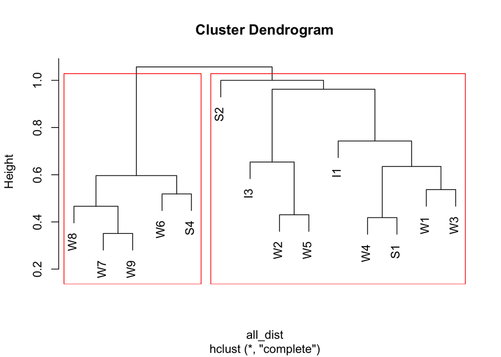

```r
all_dendrogram <- hclust(all_dist)
# 2 clusters
plot(all_dendrogram)
rect.hclust(all_dendrogram, k = 2)
```

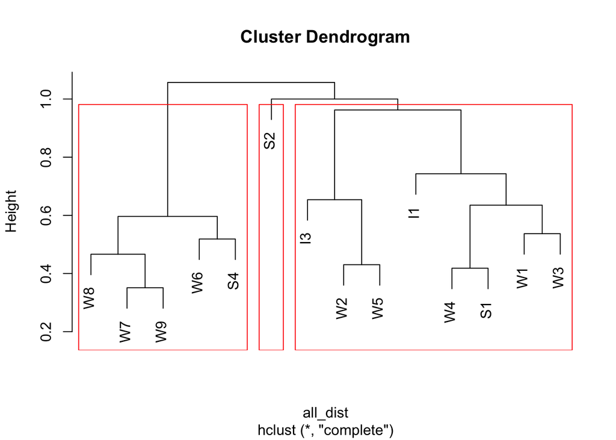

```r
# 3 clusters
plot(all_dendrogram)
rect.hclust(all_dendrogram, k = 3)
```

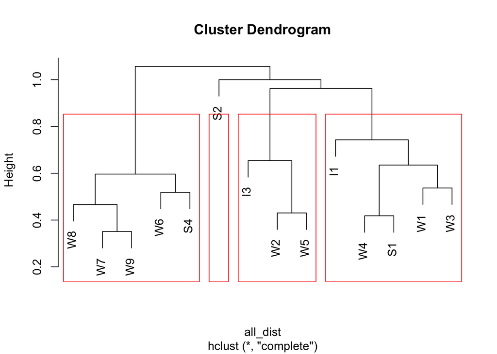

```r
# 4 clusters
plot(all_dendrogram)
rect.hclust(all_dendrogram, k = 4)
```

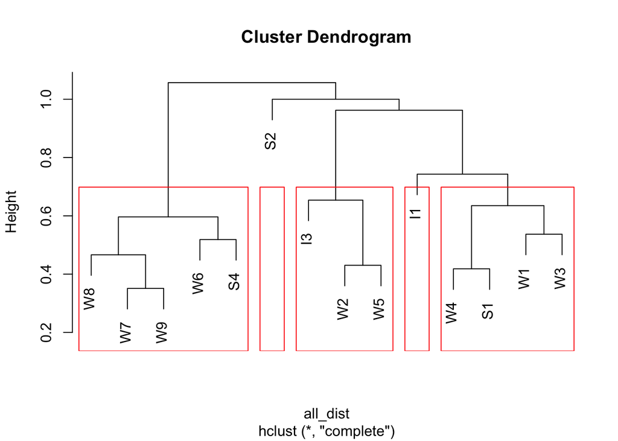

```r
plot(all_dendrogram)
rect.hclust(all_dendrogram, k = 5)
```

### Choosing the final number of structural equivalence clusters In my final (aka selected) dendrogram model, I identify 4 blocks in the network. Why? Firstly, having 4 blocks allows me to account for the 2 main cliques that were reported in Roethlisberger & Dickson (1939). And, secondly, it allows me to account for the 4 workers who were members of neither group and who generally tended to keep to themselves, according to the records by Roethlisberger & Dickson (1939).

You might be asking, why did I not just pick 3 blocks then - one for each of the two cliques and another one for the more isolated individuals? I originally tried just that but the dendrogram identified S2 as a separate block before identifying the other clique-excluded individuals in the block (when k=3). To understand this assortment, I read some notes by Roethlisberger & Dickson (1939) and they reported that Solderer 2 (S2) had a speech handicap and, in their view, S2 generally had even fewer relationship ties than the other excluded workers at the factory.

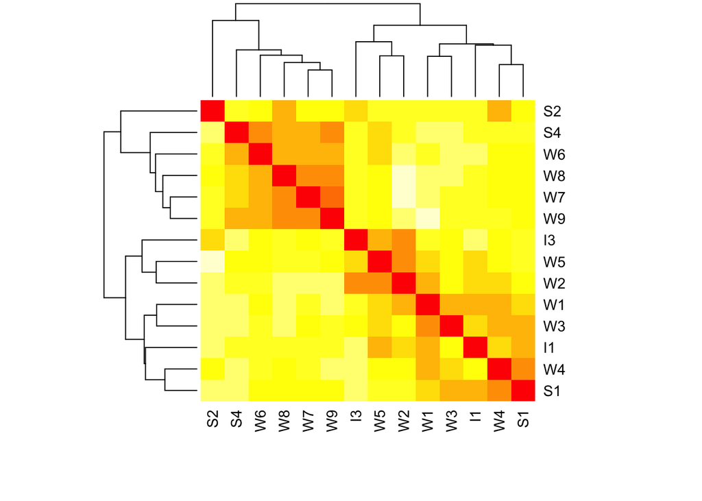

```r
all_matrix <- as.matrix(all_dist)
heatmap(all_matrix,
          denscol="black",
          trace = "none",
          margins =c(6,4),
          revC = TRUE)
```

```r
partit <- cutree(all_dendrogram, k = 4)
partit
```

```
## I1 I3 W1 W2 W3 W4 W5 W6 W7 W8 W9 S1 S2 S4
##  1  2  1  2  1  1  2  3  3  3  3  1  4  3
```

### Creating regular equivalence classes

A concept that is closely related to structural equivalence is regular equivalence. With regular equivalence, however, we look at (occupation) roles, rather than at social networks of nodes. Two workers are said to be regularly equivalent if they have the exact same occupation in the network. Said differently, inspectors in the Bank Wiring Room are regularly equivalent to one another and so are all solderers and all wiremen.

```r
hawthorne <- Node$new("Hawthorne Director")
I1 <- hawthorne$AddChild("I1")
I3 <- hawthorne$AddChild("I3")

S1 <- I1$AddChild("S1")

W1 <- S1$AddChild("W1")
W2 <- S1$AddChild("W2")
W3 <- S1$AddChild("W3")

S2 <- I3$AddChild("S2")

W4 <- S2$AddChild("W4")
W5 <- S2$AddChild("W5")
W6 <- S2$AddChild("W6")

S4 <- I3$AddChild("S4")

W7 <- S4$AddChild("W7")
W8 <- S4$AddChild("W8")
W9 <- S4$AddChild("W9")
hawthorne_ig <- as.igraph(hawthorne, directed = FALSE)
```

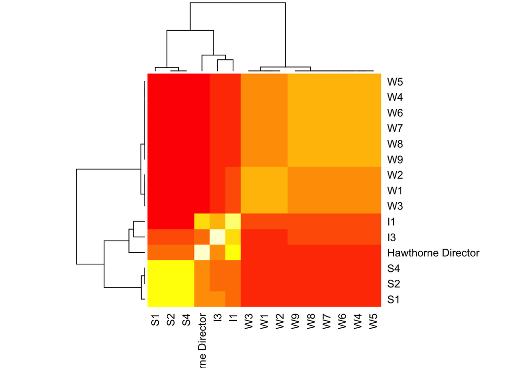

```r
hierarchy_adj <- get.adjacency(hawthorne_ig)
hierarchy_adj_matrix <- as.matrix(hierarchy_adj)
hierarchy_rege <- REGE.nm.for(hierarchy_adj_matrix)$E
heatmap(hierarchy_rege)
```

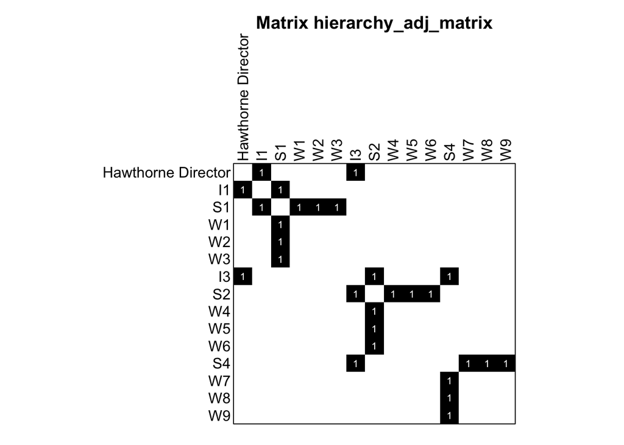

```r
plot.mat(hierarchy_adj_matrix,
         print.val = TRUE)
```

```r
hierarchy_dist <- as.dist(1 - hierarchy_rege)
hierarchy_hclust <- hclust(hierarchy_dist, method = "ward.D2")
hierarchy_clusters <- cutree(hierarchy_hclust,
                       k = 3)
```

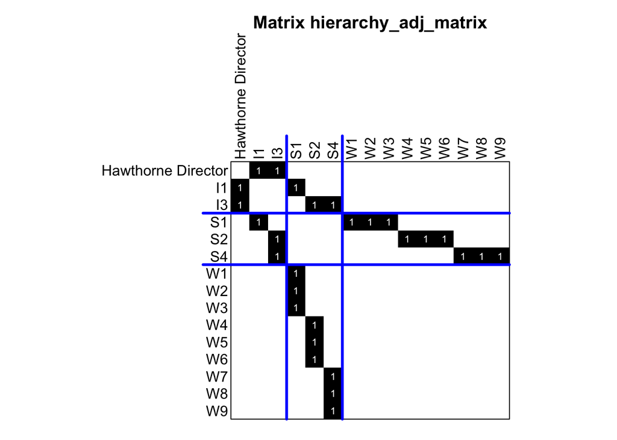

```r
plot.mat(hierarchy_adj_matrix,
         print.val = TRUE,
         clu = hierarchy_clusters)
```

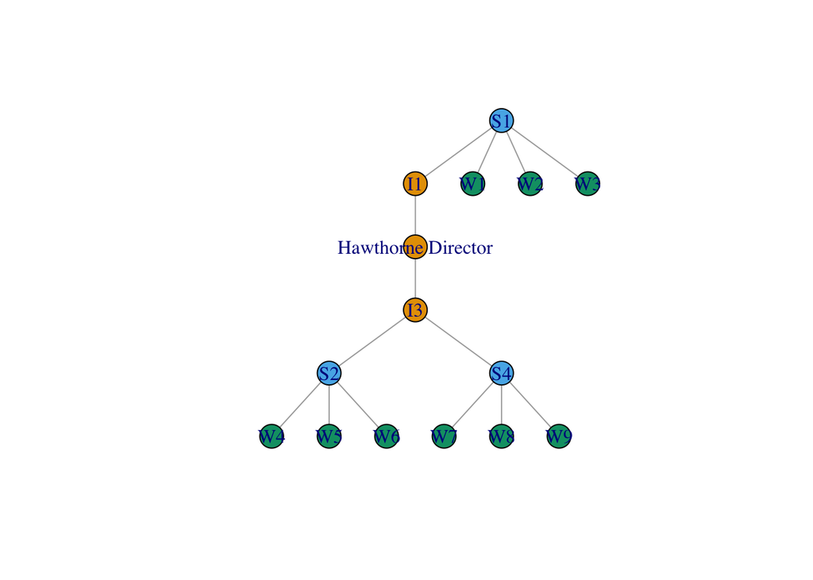

```r
plot(hawthorne_ig,
     vertex.color = hierarchy_clusters,
     layout = layout_as_tree(hawthorne_ig))
```